# Simulation Study: Single vs. Mixture Synergy Models

Yusuke Matsui

2025-06-04

# 1. Introduction

This vignette demonstrates **how to reproduce the simulation study** used in our manuscript to compare

- **Single‑subject factor models** (SingleFA, SinglePCA) and
- **Mixture models** that allow latent sub‑populations (MixtureFA, MixturePCA).

Performance is evaluated on 10 independent replicates with metrics that reflect *goodness of fit* (Bayesian Information Criterion, BIC), *clustering accuracy* (Adjusted Rand Index, ARI) and *reconstruction quality* (Variance Accounted For, VAF).

For reference, VAF is defined as

$$\mathrm{VAF} = 1 - \frac{\sum_{i}(y_i - \hat{y}_i)^2}{\sum_{i} y_i^2},$$

# 2. Simulation design

Each replicate draws $N=50$ synthetic subjects whose EMG signals are generated from **$K=4$ true clusters** sharing common factor loadings of rank $r=4$ across $M=7$ muscles. The helper function `simulate_and_compare_4methods_noTwoStep()`

- fits all four candidate models,
- initialises each mixture model with $k$‑means (`use_kmeans_init = TRUE`),
- repeats the EM algorithm `n_init = 5` times to reduce local‐optimum bias, and
- returns a tidy data frame of evaluation statistics.

Noise level (`noise_scale`) and between‑cluster separation (`cluster_sep`) can be tuned; we keep both at 1.0 for an intermediate difficulty setting.

# 3. Running the 10 replicates

```r
seeds_vec <- 101:110

res_list <- lapply(seeds_vec, function(s){
  simulate_and_compare_4methods_noTwoStep(
    N = 50, K_true = 4, r_true = 4, M = 7, T_each = 100, seed = s,
    r_singleFA  = 4, r_singlePCA = 4,
    cluster_sep = 1.0, noise_scale = 1.0,
    n_init = 5, use_kmeans_init = TRUE, mc_cores = 5
  ) %>%
    mutate(Seed = s)
})
```

[output not shown]

```r
df_all <- bind_rows(res_list)

dplyr::glimpse(df_all)
```

```
## Rows: 40
## Columns: 6
## $ Method <chr> "SingleFA", "SinglePCA", "MixtureFA", "MixturePCA", "SingleFA",…
## $ BIC    <dbl> 108434.89, 103933.03, 80354.58, 87517.04, 103921.72, 98357.75, …
## $ ARI    <dbl> NA, NA, 1, 1, NA, NA, 1, 1, NA, NA, 1, 1, NA, NA, 1, 1, NA, NA,…
## $ SSE    <dbl> 25211.855, 7327.571, 16337.644, 1833.572, 21674.680, 5256.977, …
## $ VAF    <dbl> 0.6653263, 0.9027305, 0.7831266, 0.9756603, 0.6813557, 0.922716…
## $ Seed   <int> 101, 101, 101, 101, 102, 102, 102, 102, 103, 103, 103, 103, 104…
```

We annotate two helper columns to simplify downstream plotting:

```r
df_all <- df_all %>%
  mutate(Type       = ifelse(Method %in% c("SingleFA", "SinglePCA"), "Single", "Mixture"),
         SubMethod  = ifelse(Method %in% c("SingleFA", "MixtureFA"), "FA", "PCA"))
```

# 4. Summary statistics

```r
df_summary <- df_all %>%
  group_by(Method, Type, SubMethod) %>%
  summarise(
    mean_BIC = mean(BIC),  sd_BIC = sd(BIC),
    mean_ARI = mean(ARI, na.rm = TRUE),  sd_ARI = sd(ARI, na.rm = TRUE),
    mean_VAF = mean(VAF),  sd_VAF = sd(VAF),
    .groups   = "drop"
  )

knitr::kable(df_summary, digits = 2)
```

| Method | Type | SubMethod | mean_BIC | sd_BIC | mean_ARI | sd_ARI | mean_VAF | sd_VAF |
| --- | --- | --- | --- | --- | --- | --- | --- | --- |
| MixtureFA | Mixture | FA | 75819.86 | 4881.67 | 1 | 0 | 0.79 | 0.03 |
| MixturePCA | Mixture | PCA | 83269.78 | 4648.37 | 1 | 0 | 0.97 | 0.00 |
| SingleFA | Single | FA | 104070.26 | 3871.20 | NaN | NA | 0.67 | 0.01 |
| SinglePCA | Single | PCA | 99739.96 | 3800.92 | NaN | NA | 0.91 | 0.01 |

# 5. Visualising variability across replicates

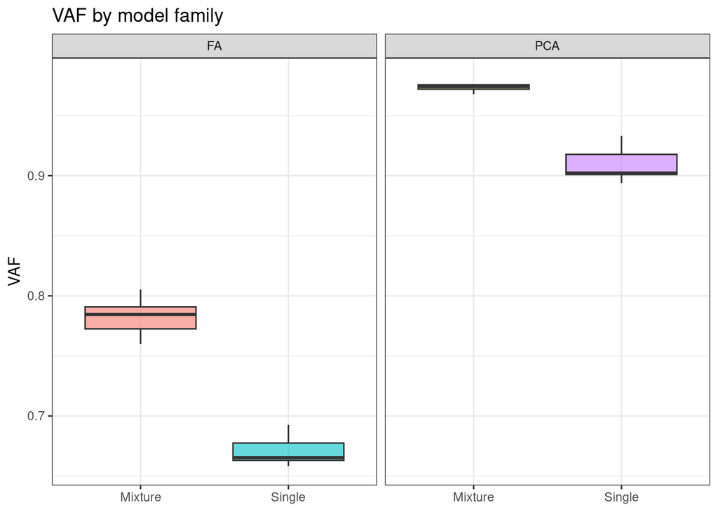

Distribution of Variance Accounted For (VAF) across 10 simulation replicates.

```r
library(ggplot2)

ggplot(df_all, aes(x = Type, y = VAF, fill = Method)) +
  geom_boxplot(alpha = 0.6, outlier.shape = NA) +
  theme_bw() +
  facet_wrap(~SubMethod) +
  labs(x = NULL, y = "VAF", title = "VAF by model family") +
  theme(legend.position = "none")
```

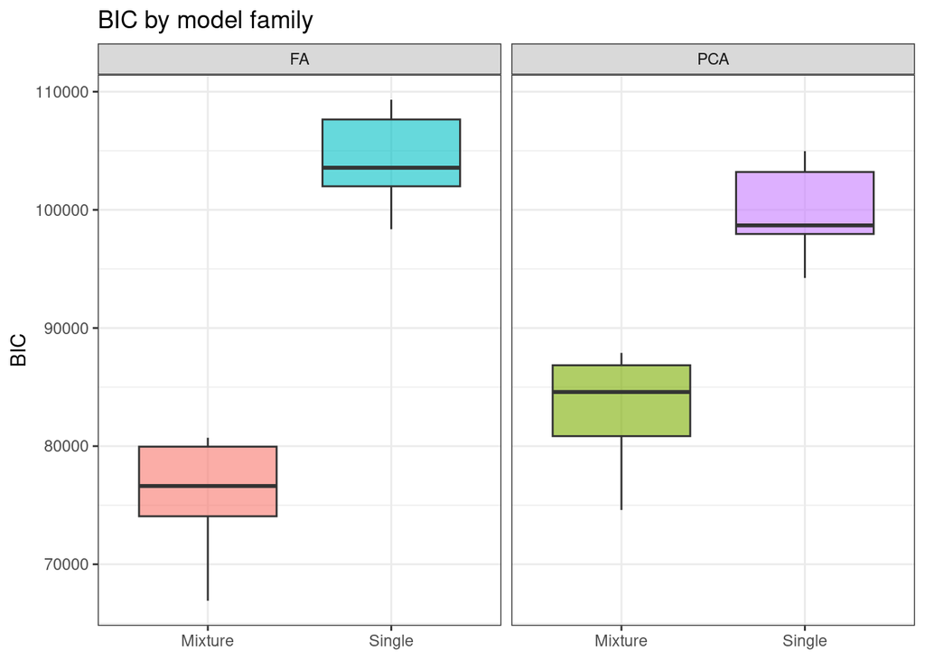

Distribution of Bayesian Information Criterion (BIC) across 10 simulation replicates.

```r
ggplot(df_all, aes(x = Type, y = BIC, fill = Method)) +
  geom_boxplot(alpha = 0.6, outlier.shape = NA) +
  theme_bw() +
  facet_wrap(~SubMethod) +
  labs(x = NULL, y = "BIC", title = "BIC by model family") +
  theme(legend.position = "none")
```

> **Interpretation.** Mixture models yield lower (better) BIC and markedly higher ARI (not shown) whenever distinct latent clusters exist. VAF differences between FA and PCA reflect method‑specific assumptions (orthogonality vs. diagonal uniqueness). In practice, the trade‑off between VAF and model complexity (BIC) suggests MixtureFA strikes the best balance for heterogeneous cohorts.